# Pełna analiza Text Mining: newsy finansowe a indeks Dow Jones

Przetwarzanie tekstu, częstość słów, TF-IDF oraz analiza sentymentu wieloma słownikami (Reproducible Research)

Kacper Tarnowski, Aleksander Mistur

08.06.2026

```r
suppressPackageStartupMessages({
  library(readr); library(dplyr); library(tidyr); library(stringr)
  library(ggplot2); library(forcats); library(scales); library(lubridate)
  library(tidytext)          # tokenizacja, TF-IDF, leksykon Bing
  library(SnowballC)         # stemming (wordStem)
  library(wordcloud)         # chmury slow
  library(reshape2)          # acast() do chmury porownawczej
  library(RColorBrewer)      # palety kolorow
  library(SentimentAnalysis) # slowniki GI, HE, LM, QDAP
  library(ggthemes)          # theme_gdocs
})
theme_set(theme_minimal(base_size = 12))
```

# 1 Wprowadzenie

Celem projektu jest pełna analiza text mining oraz analiza sentymentu newsów finansowych w zestawieniu z kierunkiem amerykańskiego indeksu **Dow Jones (DJIA)**. System wczytuje dane z pliku CSV, w którym dla każdego dnia sesyjnego (2000–2016) zebrano **25 najważniejszych nagłówków** oraz etykietę rynku (1 = DJIA wzrósł, 0 = spadł).

Skrypt łączy tradycyjne techniki przetwarzania tekstu (czyszczenie, tokenizacja, **stemming** i uzupełnienie rdzeni — *stem completion*) z oceną sentymentu przy użyciu wielu słowników: **Bing** (tidytext) oraz słowników z pakietu `SentimentAnalysis` — **GI, HE, LM, QDAP**. Stosujemy trzy techniki poznane na zajęciach: analizę częstości słów, TF-IDF oraz analizę sentymentu (z porównaniem słowników i badaniem zmian w czasie).

# 2 Wczytanie i przetwarzanie tekstu

```r
# Wczytanie dostarczonego pliku. Format szeroki: Date, Label, Top1..Top25.
raw <- read_csv("data/djia_news.csv", show_col_types = FALSE)
cat("Wymiary:", nrow(raw), "dni x", ncol(raw), "kolumn\n")
```

```
## Wymiary: 4101 dni x 27 kolumn
```

```r
raw %>% select(Date, Label, Top1, Top2) %>% slice_head(n = 3)
```

| Date | Label | Top1 | Top2 |
| --- | --- | --- | --- |
| 2000-01-03 | 0 | A 'hindrance to operations': extracts from the leaked reports | Scorecard |
| 2000-01-04 | 0 | Scorecard | The best lake scene |
| 2000-01-05 | 0 | Coventry caught on counter by Flo | United's rivals on the road to Rio |

```r
# Format szeroki -> dlugi: 1 naglowek = 1 wiersz. Czyszczenie tekstu:
# normalizacja apostrofow, usuniecie prefiksu b"...", zbednych escape'ow.
news <- raw %>%
  mutate(Date = as.Date(Date), market = if_else(Label == 1, "wzrost", "spadek")) %>%
  pivot_longer(starts_with("Top"), names_to = "rank", values_to = "headline") %>%
  filter(!is.na(headline), headline != "") %>%
  mutate(
    headline = str_replace_all(headline, "[\u2018\u2019]", "'"),   # normalizacja apostrofow
    headline = str_remove(headline, '^b["\']'),                     # prefiks bytestring
    headline = str_replace_all(headline, '\\\\["\']', "")           # zbedne escapy
  )
cat("Liczba naglowkow po przeksztalceniu:", nrow(news), "\n")
```

```
## Liczba naglowkow po przeksztalceniu: 102518
```

```r
raw %>% count(market = if_else(Label == 1, "wzrost", "spadek"), name = "liczba_dni")
```

| market | liczba_dni |
| --- | --- |
| spadek | 1935 |
| wzrost | 2166 |

```r
# Tokenizacja + usuniecie stopwords i liczb. Krotkie tokeny (<=2 znaki) odrzucamy.
data("stop_words")
tidy_news <- news %>%
  unnest_tokens(word, headline) %>%
  anti_join(stop_words, by = "word") %>%
  filter(!str_detect(word, "^[0-9]+$"), str_length(word) > 2)
cat("Tokeny:", nrow(tidy_news), "| unikalne slowa:", n_distinct(tidy_news$word), "\n")
```

```
## Tokeny: 714158 | unikalne slowa: 50275
```

```r
# Stemming: sprowadzenie slow do rdzenia (np. "markets","market" -> "market").
tidy_news <- tidy_news %>% mutate(stem = wordStem(word))

# Stem completion (typ "prevalent"): kazdemu rdzeniowi przypisujemy jego
# najczestsza forme pierwotna - zeby wyniki byly czytelne mimo stemmingu.
stem_completion <- tidy_news %>%
  count(stem, word, sort = TRUE) %>%
  group_by(stem) %>%
  slice_max(n, n = 1, with_ties = FALSE) %>%
  ungroup() %>%
  select(stem, term = word)

tidy_news <- tidy_news %>% left_join(stem_completion, by = "stem")
tidy_news %>% select(word, stem, term) %>% slice_head(n = 6)
```

| word | stem | term |
| --- | --- | --- |
| hindrance | hindranc | hindrance |
| operations | oper | operation |
| extracts | extract | extract |
| leaked | leak | leaked |
| reports | report | report |
| scorecard | scorecard | scorecard |

# 3 Technika 1 — Analiza częstości słów

```r
# Czestosc liczymy na uzupelnionych rdzeniach (term) - czytelnie i po stemmingu.
top_words <- tidy_news %>% count(term, sort = TRUE)
top_words %>% slice_head(n = 15)
```

| term | n |
| --- | --- |
| killed | 2974 |
| world | 2609 |
| government | 2392 |
| police | 2276 |
| attack | 2091 |
| israel | 2082 |
| people | 2040 |
| china | 2031 |
| protest | 1998 |
| report | 1989 |

[output cut: 5 more lines]

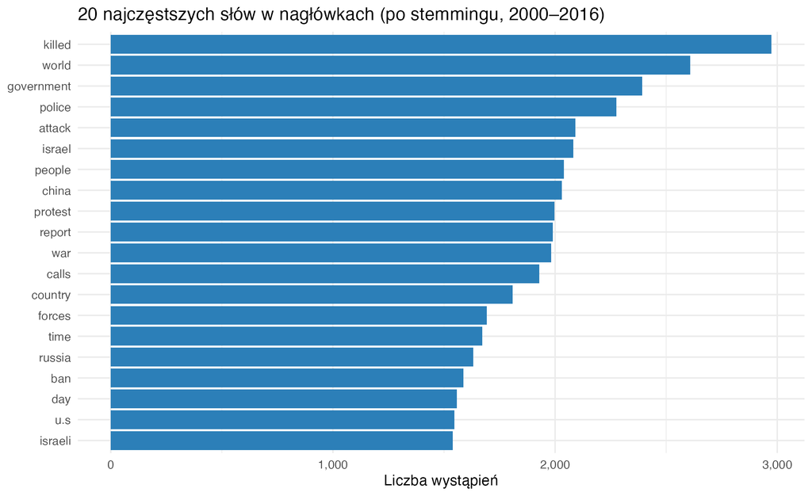

```r
top_words %>%
  slice_head(n = 20) %>%
  mutate(term = fct_reorder(term, n)) %>%
  ggplot(aes(n, term)) +
  geom_col(fill = "#2c7fb8") +
  scale_x_continuous(labels = label_comma()) +
  labs(title = "20 najczęstszych słów w nagłówkach (po stemmingu, 2000–2016)",
       x = "Liczba wystąpień", y = NULL)
```

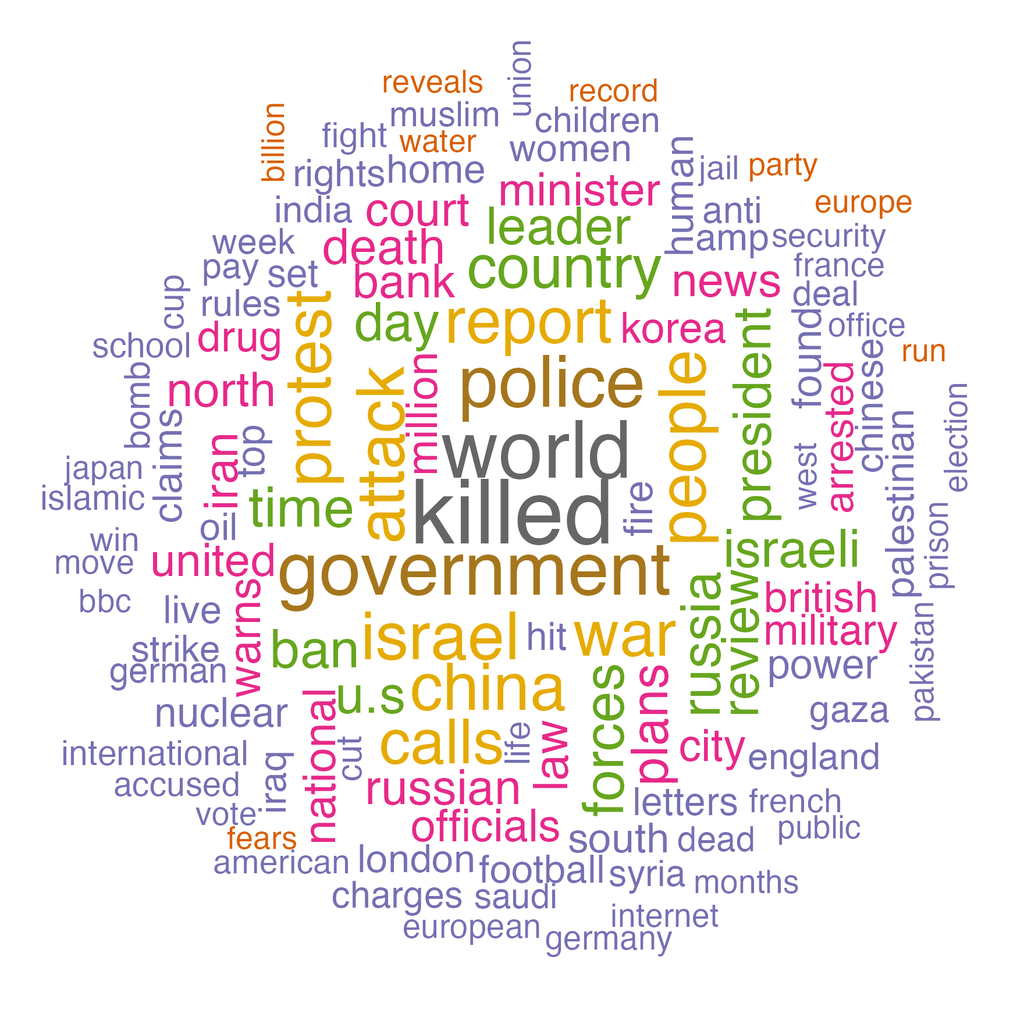

```r
with(top_words %>% slice_head(n = 120),
     wordcloud(words = term, freq = n, max.words = 120, random.order = FALSE,
               rot.per = 0.25, scale = c(4.2, 0.6), colors = brewer.pal(8, "Dark2")))
```

# 4 Technika 2 — TF-IDF (dni wzrostowe vs spadkowe)

Traktujemy nagłówki z dni wzrostowych i spadkowych jak dwa dokumenty i liczymy TF-IDF, aby znaleźć słowa najbardziej charakterystyczne dla każdego kierunku rynku.

```r
market_tf_idf <- tidy_news %>%
  count(market, term, sort = TRUE) %>%
  bind_tf_idf(term, market, n) %>%
  arrange(desc(tf_idf))
market_tf_idf %>% select(market, term, n, tf_idf) %>% slice_head(n = 12)
```

| market | term | n | tf_idf |
| --- | --- | --- | --- |
| wzrost | apr | 32 | 5.846445e-05 |
| spadek | blix | 14 | 2.898725e-05 |
| spadek | psychologist | 10 | 2.070518e-05 |
| wzrost | desecration | 11 | 2.009715e-05 |
| wzrost | shy | 11 | 2.009715e-05 |
| spadek | faso | 8 | 1.656414e-05 |
| spadek | indifference | 8 | 1.656414e-05 |
| spadek | interfering | 8 | 1.656414e-05 |
| wzrost | aipac | 9 | 1.644313e-05 |
| wzrost | broncos | 9 | 1.644313e-05 |

[output cut: 2 more lines]

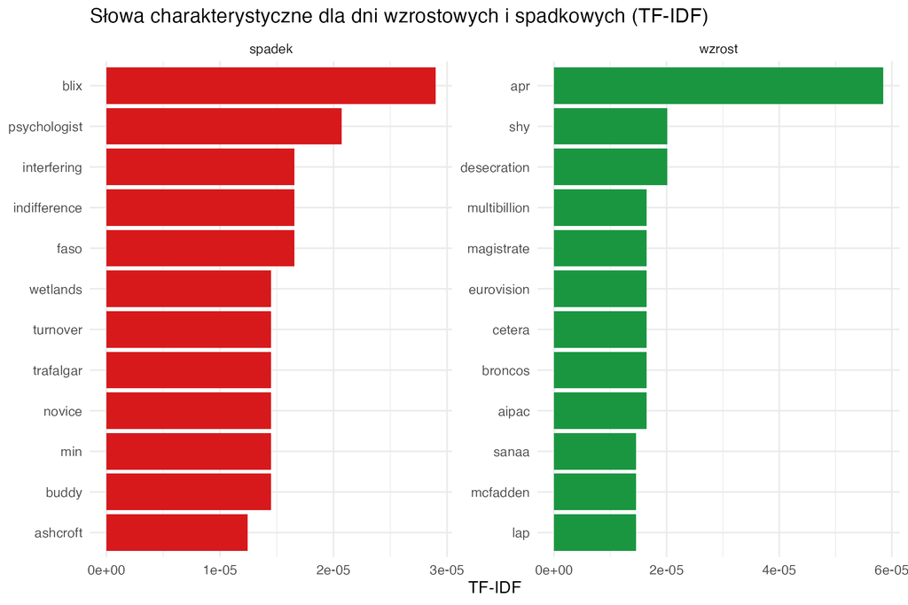

```r
market_tf_idf %>%
  group_by(market) %>%
  slice_max(tf_idf, n = 12, with_ties = FALSE) %>%
  ungroup() %>%
  mutate(term = reorder_within(term, tf_idf, market)) %>%
  ggplot(aes(tf_idf, term, fill = market)) +
  geom_col(show.legend = FALSE) +
  facet_wrap(~market, scales = "free") +
  scale_y_reordered() +
  scale_fill_manual(values = c(spadek = "#d7191c", wzrost = "#1a9641")) +
  labs(title = "Słowa charakterystyczne dla dni wzrostowych i spadkowych (TF-IDF)",
       x = "TF-IDF", y = NULL)
```

# 5 Technika 3 — Analiza sentymentu

## 5.1 Słowa wnoszące sentyment (leksykon Bing)

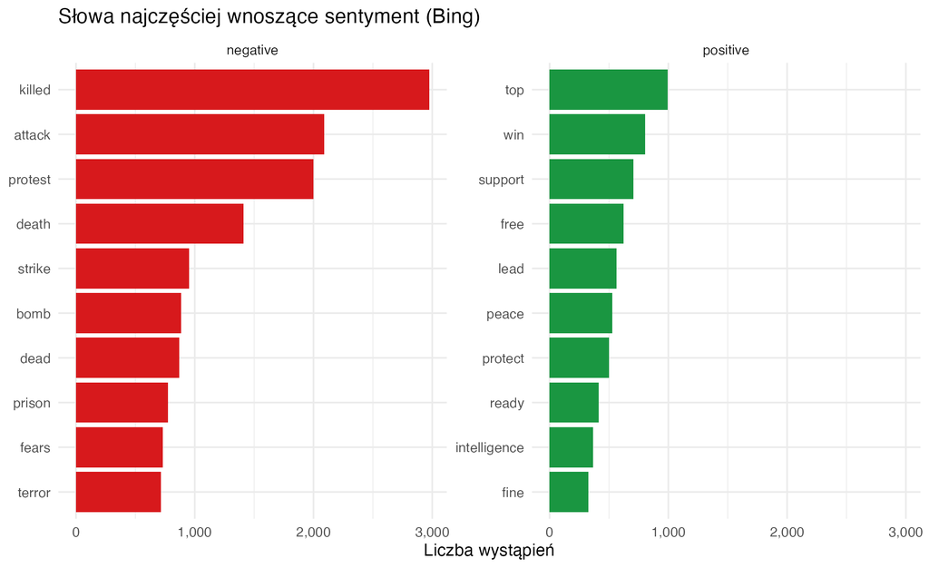

```r
bing <- get_sentiments("bing")
tidy_news %>%
  inner_join(bing, by = c("term" = "word")) %>%
  count(term, sentiment, sort = TRUE) %>%
  group_by(sentiment) %>%
  slice_max(n, n = 10, with_ties = FALSE) %>%
  ungroup() %>%
  mutate(term = reorder_within(term, n, sentiment)) %>%
  ggplot(aes(n, term, fill = sentiment)) +
  geom_col(show.legend = FALSE) +
  facet_wrap(~sentiment, scales = "free_y") +
  scale_y_reordered() + scale_x_continuous(labels = label_comma()) +
  scale_fill_manual(values = c(negative = "#d7191c", positive = "#1a9641")) +
  labs(title = "Słowa najczęściej wnoszące sentyment (Bing)", x = "Liczba wystąpień", y = NULL)
```

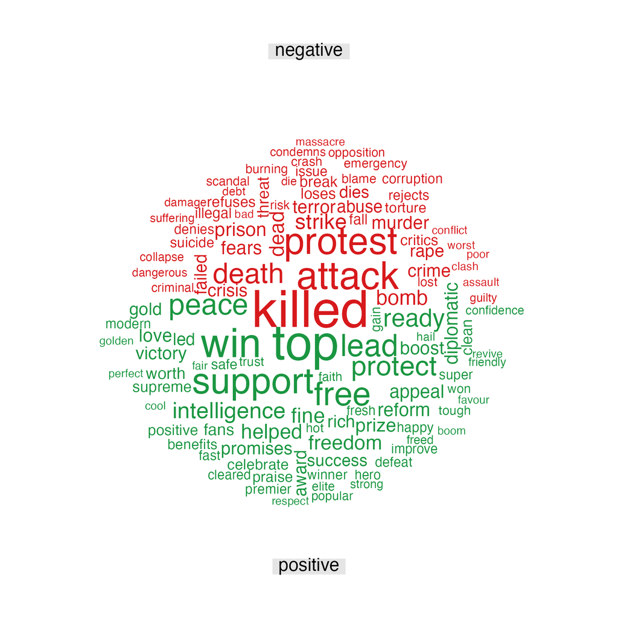

```r
tidy_news %>%
  inner_join(bing, by = c("term" = "word")) %>%
  count(term, sentiment, sort = TRUE) %>%
  acast(term ~ sentiment, value.var = "n", fill = 0) %>%
  comparison.cloud(colors = c("#d7191c", "#1a9641"),
                   max.words = 120, scale = c(4, 0.6), title.size = 1.4)
```

## 5.2 Sentyment wieloma słownikami (GI, HE, LM, QDAP)

Łączymy 25 nagłówków danego dnia w jeden tekst i oceniamy go słownikami pakietu `SentimentAnalysis`. Pozwala to **porównać wyniki różnych słowników**.

```r
daily_text <- news %>%
  group_by(Date, market) %>%
  summarise(text = str_c(headline, collapse = ". "), .groups = "drop")

# Jedno wywolanie liczy wszystkie 4 slowniki naraz.
sent <- analyzeSentiment(daily_text$text)
scores <- daily_text %>%
  mutate(GI = sent$SentimentGI, HE = sent$SentimentHE,
         LM = sent$SentimentLM, QDAP = sent$SentimentQDAP)
head(scores %>% select(Date, GI, HE, LM, QDAP))
```

| Date | GI | HE | LM | QDAP |
| --- | --- | --- | --- | --- |
| 2000-01-03 | -0.16822430 | -0.009345794 | -0.07476636 | -0.08411215 |
| 2000-01-04 | -0.04301075 | 0.000000000 | -0.10752688 | -0.07526882 |
| 2000-01-05 | -0.01086957 | 0.010869565 | -0.02173913 | 0.01086957 |
| 2000-01-06 | -0.06194690 | 0.008849558 | -0.08849558 | -0.02654867 |
| 2000-01-07 | -0.05000000 | 0.000000000 | -0.01250000 | -0.06250000 |
| 2000-01-10 | -0.08163265 | -0.020408163 | -0.06122449 | -0.07142857 |

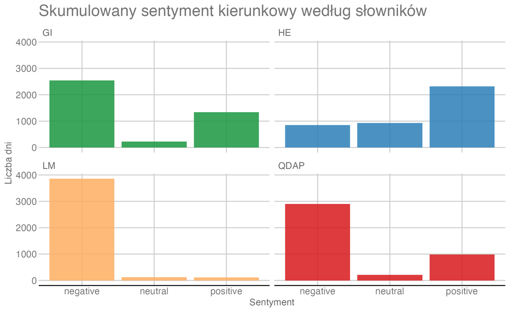

```r
# convertToDirection: wartosc ciagla -> kierunek (pozytywny/neutralny/negatywny).
direction <- scores %>%
  pivot_longer(c(GI, HE, LM, QDAP), names_to = "Dictionary", values_to = "value") %>%
  mutate(direction = as.character(convertToDirection(value))) %>%
  filter(!is.na(direction))

ggplot(direction, aes(direction, fill = Dictionary)) +
  geom_bar(alpha = 0.85, show.legend = FALSE) +
  facet_wrap(~Dictionary) +
  scale_fill_manual(values = c(GI="#1a9641", HE="#2c7fb8", LM="#fdae61", QDAP="#d7191c")) +
  theme_gdocs() +
  labs(title = "Skumulowany sentyment kierunkowy według słowników",
       x = "Sentyment", y = "Liczba dni")
```